# XGBoost

Harrison Cradduck, Nick Berry

2025-11-07

# 1 Introduction

**Using the methods we discussed in class, develop the best XGBoost model that you can. Tune hyperparameters to improve model performance.**

# 2 Loading in Data

```r
# read in training and holdout datsets
train <- readr:: read_rds('decision_tree_train.rds')
holdout <- readr::read_rds('decision_tree_holdout.rds')
```

```r
# set seed for ability to reproduce modeling
set.seed(123)
```

# 3 Downsampling

**For our XGBoost models we decided to move forward with just the downsampled data for the sake of computational complexity**

```r
train.ds <- caret::downSample(x = train %>%
                    dplyr::select(-loan_default),
                  y = train$loan_default,
                  yname = "loan_default")
table(train.ds$loan_default)
```

```
##
##    No   Yes
## 46620 46620
```

# 4 1-Hot Dummy Encoding

## 4.1 Training Data

```r
# creating dummies on the training data
dummies <- caret::dummyVars(~ . - loan_default,
                            data = train.ds,
                            fullRank = FALSE)
# excluding the response variable so it remains in the same form in all our models
```

```r
# making the dataframe for the dummies and reintroducing the observed class
train.dummy <- data.frame(predict(dummies, newdata = train.ds))

train.dummy <- cbind(train.dummy, loan_default = train.ds$loan_default)
```

## 4.2 Holdout Data

```r
# creating dummies on the holdout data
dummies <- caret::dummyVars(~ . - loan_default,
                            data = holdout,
                            fullRank = FALSE)
```

```r
# making the dataframe for the dummies and reintroducing the observed class
holdout.dummy <- data.frame(predict(dummies, newdata = holdout))

holdout.dummy <- cbind(holdout.dummy, loan_default = holdout$loan_default)
```

# 5 Modeling

```r
# setting up parallel processing
cores = parallel::detectCores()
cores
```

```
## [1] 48
```

```r
c1 <- parallel::makeCluster(8)
registerDoParallel(c1)
```

## 5.1 XGBoost Model on Ragular, Downsampled Data

```r
# set up train control for 10 fold cross validation
cv_control <- trainControl(method = 'cv', number = 10, allowParallel = TRUE)
```

```r
# train XGBoost model with cross validation on downsampled training data
# xgb_model <- caret::train(
#   loan_default ~ .,
#   data = train.ds,
#   method = 'xgbTree',
#   trControl = cv_control,
#   tuneLength = 5
# )

# saveRDS(xgb_model, 'xgboost.rds')
```

## 5.2 XGBoost on 1-Hot Dummy Enocded, Downsampled Data

```r
# train XGBoost model with cross validation on 1-hot dummy encoded, downsampled training data
# xgb_dmy_model <- caret::train(
#   loan_default ~ .,
#   data = train.dummy,
#   method = 'xgbTree',
#   trControl = cv_control,
#   tuneLength = 5
# )
# saveRDS(xgb_dmy_model, 'XGBoost_dmy.rds')
```

```r
# stop parallel processing
stopCluster(c1)
registerDoSEQ()
```

# 6 Model Evaluation

## 6.1 Downsampled Data

```r
# reading in the previously saved model
xgb_model <- read_rds('xgboost.rds')
```

```r
#printing the hyperparameters selected
print(xgb_model$bestTune)
```

```
##     nrounds max_depth eta gamma colsample_bytree min_child_weight subsample
## 125     250         3 0.3     0              0.6                1         1
```

```r
# read in the predictions from the pruned decision trees
pred.holdout <- readr::read_rds('holdout_predictions.rds')
```

```r
# save predicted probability for the holdout data
pred.holdout$xgb_prob <- predict(xgb_model,
                                   newdata = holdout,
                                   type = 'prob')[,'Yes']
```

```r
# computing ROC of curve
pred <- ROCR::prediction(pred.holdout$xgb_prob,
                         pred.holdout$loan_default)
perf <- ROCR::performance(pred, 'tpr', 'fpr')
```

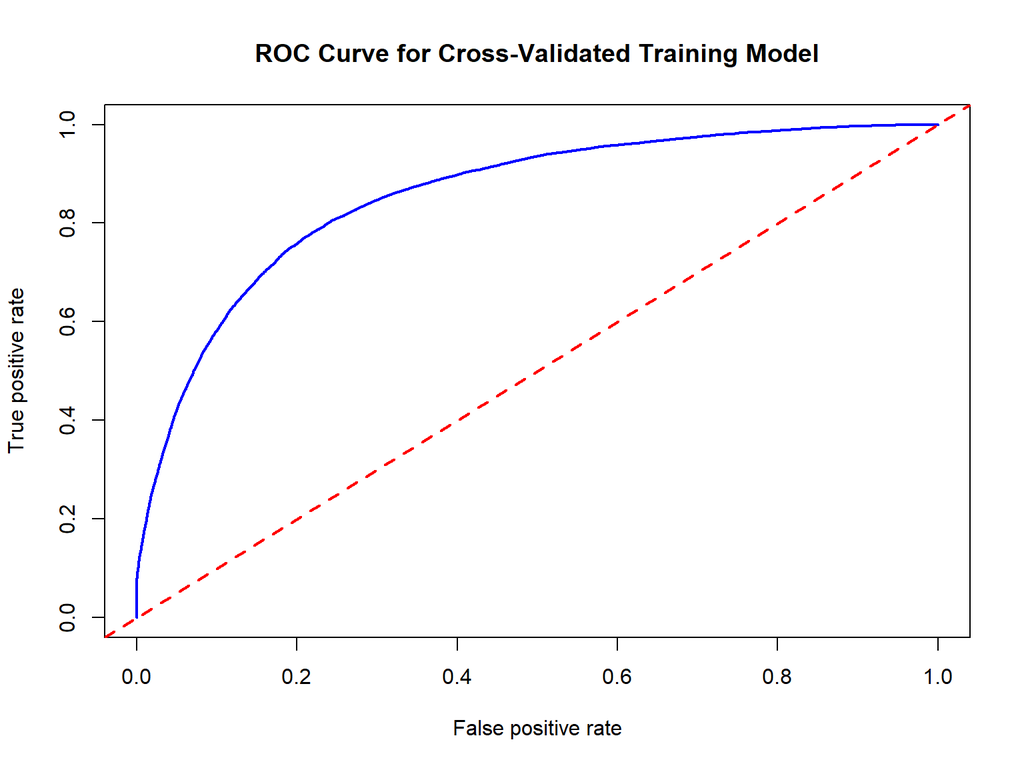

```r
# plotting ROC curve
plot(perf, col = 'blue', lwd = 2, main = 'ROC Curve for Cross-Validated Training Model')
abline(a = 0, b = 1, col = 'red', lty = 2, lwd =2)
```

```r
# AUC of above curve
ROCR::performance(pred, 'auc')@y.values[[1]]
```

```
## [1] 0.8562062
```

```r
# finding the optimal threshold

#finding precision and recall
prec <- ROCR::performance(pred, 'prec')
rec <- ROCR::performance(pred, 'rec')

# extracting precision and recall
precision <- prec@y.values[[1]]
recall <- rec@y.values[[1]]

#compute F1
f1 = 2 * precision * recall / (precision + recall)
f1[is.nan(f1)] = 0

# combine F1 and cuttofs
cutoffs = prec@x.values[[1]]
df_f1 = data.frame(f1, cutoffs)

# find the optimal F1 index, F1 score , and cutoff
opt_idx <- which.max(f1)
opt_f1 <- df_f1[opt_idx,]
opt_f1
```

|  | f1 | cutoffs |
| --- | --- | --- |
| 20661 | 0.5968023 | 0.6110328 |

```r
best_thresh <- .6110328
pred.holdout$xgb_class <- factor(
  ifelse(pred.holdout$xgb_prob >= best_thresh,
         'Yes', 'No'))
```

```r
# print a confusion matrix for the model trained on downsampled data
caret::confusionMatrix(pred.holdout$xgb_class,
                       pred.holdout$loan_default,
                       positive = 'Yes')
```

```
## Confusion Matrix and Statistics
##
##           Reference
## Prediction    No   Yes
##        No  53792  4730
##        Yes  9871 10806
##
##                Accuracy : 0.8156
##                  95% CI : (0.8129, 0.8183)
##     No Information Rate : 0.8038
##     P-Value [Acc > NIR] : < 2.2e-16
##
##                   Kappa : 0.4804
##
##  Mcnemar's Test P-Value : < 2.2e-16
##
##             Sensitivity : 0.6955
##             Specificity : 0.8449
##          Pos Pred Value : 0.5226
##          Neg Pred Value : 0.9192
##              Prevalence : 0.1962
##          Detection Rate : 0.1364
##    Detection Prevalence : 0.2611
##       Balanced Accuracy : 0.7702
##
##        'Positive' Class : Yes
##
```

**The model trained on the regular downsampled data has an optimal predicted probability threshold of 0.6110328 based on maximizing the f1 score, which was 0.5968023. The other important metrics are as follow: AUC = 0.8562062, Accuracy = 0.8156, Sensitivity = 0.6955, Specificity = 0.8449**

```r
# variable importance
caret::varImp(xgb_model, type = 2)
```

```
## xgbTree variable importance
##
##   only 20 most important variables shown (out of 97)
##
##                                     Overall
## last_credit_pull_d_years_since     100.0000
## int_rate                            29.4036
## debt_settlement_flagY               27.9838
## issue_d_years_since                 12.0154
## term5 Years                         11.5515
## fico_range_avg                       7.9981
## dti                                  7.1111
## annual_inc                           5.3339
## revol_bal                            2.9381
## loan_amnt                            2.6698
## emp_lengthUnreported                 2.2359
## revol_util                           1.8673
## mort_acc_NA                          1.7963
## home_ownershipRENT                   1.5136
## closed_acc                           1.1030
## earliest_cr_line_years_since         1.0701
## open_acc                             0.9011
## inq_last_6mths2+                     0.3849
## mort_acc5+                           0.2833
## verification_statusSource Verified   0.1944
```

**We evaluated the variable importance for the model and fount that years since last credit pull was by far the most important variable in the model with interest rate and debt settlement flag (yes) being the next most important variables**

## 6.2 1-Hot Dummy Encoded, Downsampled Model

```r
xgb_dmy_model <- read_rds('XGBoost_dmy.rds')
```

```r
#printing the hyperparameters selected
print(xgb_dmy_model$bestTune)
```

```
##     nrounds max_depth eta gamma colsample_bytree min_child_weight subsample
## 174     200         4 0.3     0              0.6                1         1
```

```r
# save predicted probability for the dummy encoded holdout data
pred.holdout$xgb_dmy_prob <- predict(xgb_dmy_model,
                                   newdata = holdout.dummy,
                                   type = 'prob')[,'Yes']
```

```r
# computing ROC of curve
pred2 <- ROCR::prediction(pred.holdout$xgb_dmy_prob,
                         pred.holdout$loan_default)
perf2 <- ROCR::performance(pred, 'tpr', 'fpr')
```

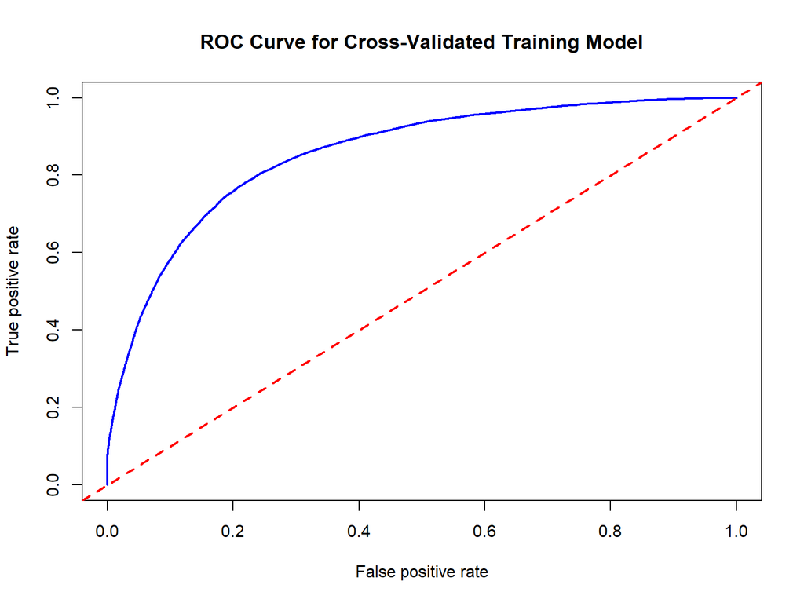

```r
# plotting ROC curve
plot(perf2, col = 'blue', lwd = 2, main = 'ROC Curve for Cross-Validated Training Model')
abline(a = 0, b = 1, col = 'red', lty = 2, lwd =2)
```

```r
# AUC of above curve
ROCR::performance(pred2, 'auc')@y.values[[1]]
```

```
## [1] 0.8562651
```

```r
# finding the optimal threshold

#finding precision and recall
prec <- ROCR::performance(pred2, 'prec')
rec <- ROCR::performance(pred2, 'rec')

# extracting precision and recall
precision <- prec@y.values[[1]]
recall <- rec@y.values[[1]]

#compute F1
f1 = 2 * precision * recall / (precision + recall)
f1[is.nan(f1)] = 0

# combine F1 and cuttofs
cutoffs = prec@x.values[[1]]
df_f1 = data.frame(f1, cutoffs)

# find the optimal F1 index, F1 score , and cutoff
opt_idx <- which.max(f1)
opt_f1 <- df_f1[opt_idx,]
opt_f1
```

|  | f1 | cutoffs |
| --- | --- | --- |
| 19241 | 0.5992124 | 0.6436434 |

```r
best_thresh <- 0.6436434
pred.holdout$xgb_dmy_class <- factor(
  ifelse(pred.holdout$xgb_dmy_prob >= best_thresh,
         'Yes', 'No'))
```

```r
# print a confusion matrix for the model trained on dummy encoded data
caret::confusionMatrix(pred.holdout$xgb_dmy_class,
                       pred.holdout$loan_default,
                       positive = 'Yes')
```

```
## Confusion Matrix and Statistics
##
##           Reference
## Prediction    No   Yes
##        No  54833  5114
##        Yes  8830 10422
##
##                Accuracy : 0.8239
##                  95% CI : (0.8213, 0.8266)
##     No Information Rate : 0.8038
##     P-Value [Acc > NIR] : < 2.2e-16
##
##                   Kappa : 0.488
##
##  Mcnemar's Test P-Value : < 2.2e-16
##
##             Sensitivity : 0.6708
##             Specificity : 0.8613
##          Pos Pred Value : 0.5413
##          Neg Pred Value : 0.9147
##              Prevalence : 0.1962
##          Detection Rate : 0.1316
##    Detection Prevalence : 0.2431
##       Balanced Accuracy : 0.7661
##
##        'Positive' Class : Yes
##
```

```r
# variable importance
caret::varImp(xgb_dmy_model, type = 2)
```

```
## xgbTree variable importance
##
##   only 20 most important variables shown (out of 112)
##
##                                 Overall
## last_credit_pull_d_years_since 100.0000
## int_rate                        27.1030
## debt_settlement_flag.N          24.1771
## issue_d_years_since             12.0742
## debt_settlement_flag.Y           8.4356
## dti                              6.8261
## term.3.Years                     6.5078
## fico_range_avg                   4.8366
## annual_inc                       4.6548
## revol_bal                        4.0384
## loan_amnt                        3.1374
## revol_util                       2.9030
## emp_length.Unreported            2.0911
## earliest_cr_line_years_since     1.6013
## closed_acc                       1.5981
## term.5.Years                     1.5910
## open_acc                         1.2857
## home_ownership.MORTGAGE          0.9824
## home_ownership.RENT              0.7565
## mort_acc_NA                      0.6516
```

**We evaluated the variable importance for the model and fount that years since last credit pull was by far the most important variable in the model with interest rate and debt settlement flag (no) being the next most important variables**

```r
#saving holdout dataframe to be used with other models
saveRDS(pred.holdout, 'holdout_predictions.rds')
```

# 7 Model Comparison

```r
# comparing the important model metrics into one dataframe

# saving the observed classifications
truth <- pred.holdout$loan_default

# Get model names based on .prob columns
model_names <- names(pred.holdout) %>%
  stringr::str_subset("\\_prob$") %>%
  stringr::str_remove("\\_prob$")

# Function to compute metrics for each model
get_metrics <- function(model_name) {
  prob_col <- paste0(model_name, "_prob")
  class_col <- paste0(model_name, "_class")

  # Extract predictions
  prob <- pred.holdout[[prob_col]]
  pred <- factor(pred.holdout[[class_col]], levels = c("No", "Yes"))

  # Confusion matrix
  cm <- caret::confusionMatrix(pred, truth, positive = "Yes")

  # AUC
  roc_obj <- pROC::roc(truth, prob, quiet = TRUE)

  # Metrics
  data.frame(
    Model = model_name,
    Accuracy = cm$overall["Accuracy"],
    Sensitivity = cm$byClass["Sensitivity"],
    Specificity = cm$byClass["Specificity"],
    F1 = MLmetrics::F1_Score(
      y_pred = pred,
      y_true = truth,
      positive = "Yes"
    ),
    AUC = as.numeric(roc_obj$auc)
  )
}

# Apply to all models
results_df <- dplyr::bind_rows(lapply(model_names, get_metrics))

# Remove row names and display
rownames(results_df) <- NULL
print(results_df[3:4,])
```

```
##     Model  Accuracy Sensitivity Specificity        F1       AUC
## 3     xgb 0.8156416   0.6955458   0.8449492 0.5968023 0.8562062
## 4 xgb_dmy 0.8239372   0.6708290   0.8613009 0.5991721 0.8562651
```

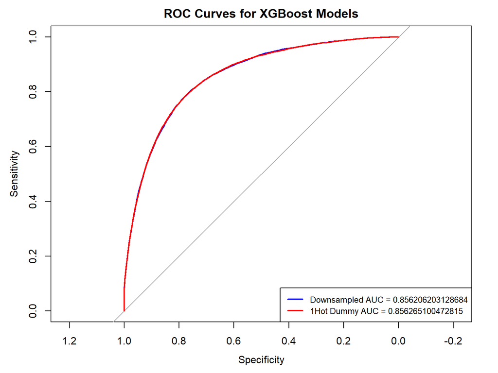

```r
# compare models by plotting ROC curves
roc_ds <- pROC::roc(holdout$loan_default,
                    predict(xgb_model,
                            holdout,
                            type = "prob")[, "Yes"])
roc_ds_dmy <- pROC::roc(holdout.dummy$loan_default,
                        predict(xgb_dmy_model,
                                holdout.dummy,
                                type = "prob")[, "Yes"])

plot(roc_ds, col = "blue", lwd = 2, main = "ROC Curves for XGBoost Models")
plot(roc_ds_dmy, add = TRUE, col = "red", lwd = 2)

legend("bottomright",
       legend = c(
         paste0("Downsampled AUC = ",
                ROCR::performance(pred, 'auc')@y.values[[1]]),
         paste0("1Hot Dummy AUC = ",
                ROCR::performance(pred2, 'auc')@y.values[[1]])
       ),
       col = c("blue", "red", "darkgreen"),
       lwd = 2,
       cex = 0.8)
```

**Both models perform similarly across all of the metrics that we are evaluating with the greatest difference between any metric for the 2 models being 0.025. There is almost no visible deviation from the two ROC lines plotted above.**

# 8 Final Model

**Since we are most concerned about maximizing the f1 score for out models in this project, the XGBoost model fit on the 1-hot dummy encoded performed just slightly better with and f1 of 0.5991721. This model also performed slightly better on all of our other metrics except for sensitivity in which it performed slightly worse.**